# Analysis of Blog Contents of Data Science Websites

Richard Soon

Sunday, November 08, 2015

# Summary

This document aims to analyze the contents of blogs on data science websites(http://www.datasciencecentral.com/, http://www.analyticbridge.com/, http://www.bigdatanews.com/), and distill top keywords from the contents by TfIdf weights. Then based on the keyword list, we build a table which recorded the TfIdf wieghts of keywords in each blog. Finally, we do certain clustering work on those blogs in terms of keywords weights.

# Data Acquisition

Ahead of this analysis, I have already scraped the links, contents and popularity of blogs by Python, mainly using “urllib2”, “cookie”, “BeautifulSoup” modules. Considering that I just finished my Natural Language Processing Capstone project through R several months ago, I will still use R and relevant packages(tm, RWeka and etc) to handle this analysis.

# Data Cleaning

Now there’re three packs of blogs from the websites mentioned above, first we load them into corpus.

```r
library(tm)
path<-"Blogs"
blogs<-Corpus(DirSource(path,encoding="utf-8",recursive=T),readerControl = list(reader = readPlain,language="en"))
blogs
```

```
## <<VCorpus>>
## Metadata:  corpus specific: 0, document level (indexed): 0
## Content:  documents: 3324
```

There are 3324 articles in total. Let’s have a look at the corpus. First try to figure out the number of characters in each blog.

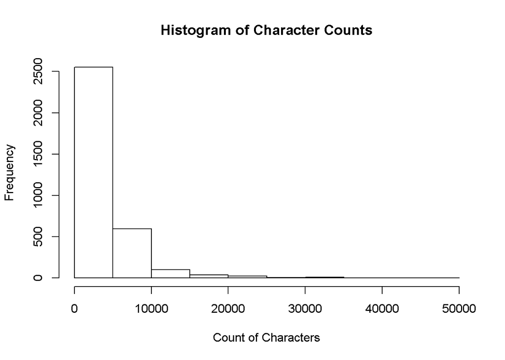

```r
getLength<-function(x){nchar(x[[1]][1])}#Get the length
lens<-sapply(blogs$content,getLength)#Get character counts of reach blog
hist(lens,xlab="Count of Characters",main="Histogram of Character Counts")#Histogram
```

```r
sum(lens<50)#How many blogs with characters fewer than 50
```

```
## [1] 21
```

```r
blogs$content<-blogs$content[lens>=50]
blogs$content[[1]][1]
```

```
## $content
## [1] "I join inhttp://www.meetup.com/R-Usersand explore its pages. I find something that wonder me: RApache !I google it and findhttp://rapache.net/.rapache is a project supporting web application development using the R statistical language and environment and the Apache web server.I am downloadi…
```

Next remove extra spaces, foreign language signs, numbers as they are not important for text analysis. Finally, we need transform all the letters into lower forms.

```r
blogs<-tm_map(blogs,content_transformer(stripWhitespace))
blogs<-tm_map(blogs,content_transformer(removeNumbers))
replacewords<-function(line,wordA,wordB){gsub(wordA,wordB,line)}
blogs<-tm_map(blogs,content_transformer(replacewords),"[^0-9a-zA-Z,.:!?'’ -@$&]"," ")
blogs<-tm_map(blogs,content_transformer(tolower))
```

# Find the most frequent words by TfIdf weights

Actually, we can directly get keywords through Google Analytic or Baidu Analytic tools. Here, we would rather explore the contents of blogs by ourselves. First get the term matrix and find out frequent words.

```r
tdm<-TermDocumentMatrix(blogs)
tdm
```

```
## <<TermDocumentMatrix (terms: 148681, documents: 3303)>>
## Non-/sparse entries: 918275/490175068
## Sparsity           : 100%
## Maximal term length: 3380
## Weighting          : term frequency (tf)
```

```r
head(findFreqTerms(tdm,1000,Inf),100)
```

```
##   [1] "&amp;"       "about"       "all"         "also"        "analysis"
##   [6] "analytic"    "analytics"   "analytics,"  "and"         "any"
##  [11] "are"         "based"       "because"     "been"        "being"
##  [16] "best"        "better"      "between"     "big"         "both"
##  [21] "business"    "but"         "can"         "companies"   "company"
##  [26] "could"       "create"      "customer"    "data"        "data,"
##  [31] "data."       "decision"    "different"   "does"        "each"
##  [36] "even"        "every"       "few"         "find"        "first"
##  [41] "for"         "from"        "get"         "good"        "had"
##  [46] "hadoop"      "has"         "have"        "help"        "how"
##  [51] "important"   "information" "into"        "its"         "job"
##  [56] "just"        "know"        "large"       "learning"    "like"
##  [61] "machine"     "make"        "management"  "many"        "market"
##  [66] "marketing"   "may"         "might"       "model"       "models"
##  [71] "more"        "most"        "much"        "need"        "new"
##  [76] "not"         "now"         "number"      "one"         "only"
##  [81] "other"       "our"         "out"         "over"        "people"
##  [86] "predictive"  "process"     "provide"     "real"        "research"
##  [91] "right"       "same"        "science"     "scientist"   "scientists"
##  [96] "see"         "set"         "should"      "social"      "software"
```

Many of them are stop words, also many punctuations exist in the words, let’s remove stopwords and punctuations. “tm” package provides a list of stop words in English, French and etc, but it is not enough. Therefore, I have searched a large volume of stop words online and saved it in a local path.

```r
length(stopwords("en"))#Original stop word count
```

```
## [1] 174
```

```r
suppressWarnings(myStopwords<-readLines("stopwords.txt"))#My stop words
length(myStopwords)
```

```
## [1] 524
```

```r
blogs<-tm_map(blogs,content_transformer(removeWords),myStopwords)#remove stopwords
```

Instead of analyzing the frequence of terms directly, we use TfIdf weighting method which can eliminate the influence of irrelevant words. We filter sparse words and confine the lengths of words so as to speed up the splitting process.

```r
tdm<-TermDocumentMatrix(blogs,control=list(removePunctuation=T,stopwords=T,minDocFreq=5,wordLengths = c(2, 20), weighting = function(x) weightTfIdf(x, normalize = FALSE)))# Remove punctuation and extreme long words
wc<-as.matrix(removeSparseTerms(tdm,0.9))
v<-sort(rowSums(wc),decreasing=T)
frequentWords<-head(v,100)
frequentWords
```

```
##          data     analytics       science           big      business
##      9063.743      8873.529      7793.117      7580.746      6256.620
##      learning         model   information        hadoop      analysis
##      5168.112      4751.544      4469.346      4443.221      4380.371
##          time    predictive     scientist        people        mining
##      4362.252      4331.257      4306.567      4289.248      4264.894
##    scientists       machine    statistics      customer     companies
##      4241.367      4037.870      4029.254      4020.880      4001.228
##        social        number           amp       process       company
##      3662.854      3649.409      3584.996      3524.162      3515.188
##     marketing    management          text      software        models
##      3472.224      3453.550      3448.851      3441.135      3427.330
##      database        system      decision     customers         tools
##      3410.729      3409.750      3391.512      3366.833      3365.758
##           set      research          make           web   statistical
##      3360.194      3321.929      3272.974      3272.803      3196.055
##        google           job         based        market    technology
##      3165.063      3150.066      3138.176      3122.560      3062.173
##          work       problem       systems        events         large
##      3056.144      3039.650      3029.199      3014.890      2974.365
##       product          code          good         users       network
##      2964.250      2963.704      2957.229      2939.801      2923.236
##  organization         world           top  intelligence   performance
##      2904.176      2885.755      2871.906      2870.326      2837.142
##    algorithms         sales          find          real      modeling
##      2816.953      2815.268      2767.771      2759.736      2753.204
##       results       quality organizations       project          user
##      2725.791      2719.643      2715.606      2705.625      2691.710
##     important      services          team         years        search
##      2673.252      2671.704      2663.922      2653.354      2630.402
##      insights      analytic         media    understand       metrics
##      2619.958      2604.001      2573.623      2556.874      2551.973
##      articles     knowledge       service      industry    experience
##      2547.728      2534.740      2520.980      2504.973      2498.494
##          book        things      approach           key          case
##      2490.116      2486.634      2485.494      2471.507      2469.580
##    techniques          cost          risk        change       article
##      2461.158      2460.989      2449.914      2448.841      2447.723
##  applications          year          part        online        create
##      2444.137      2443.032      2442.012      2434.684      2432.593
```

# Words Cloud

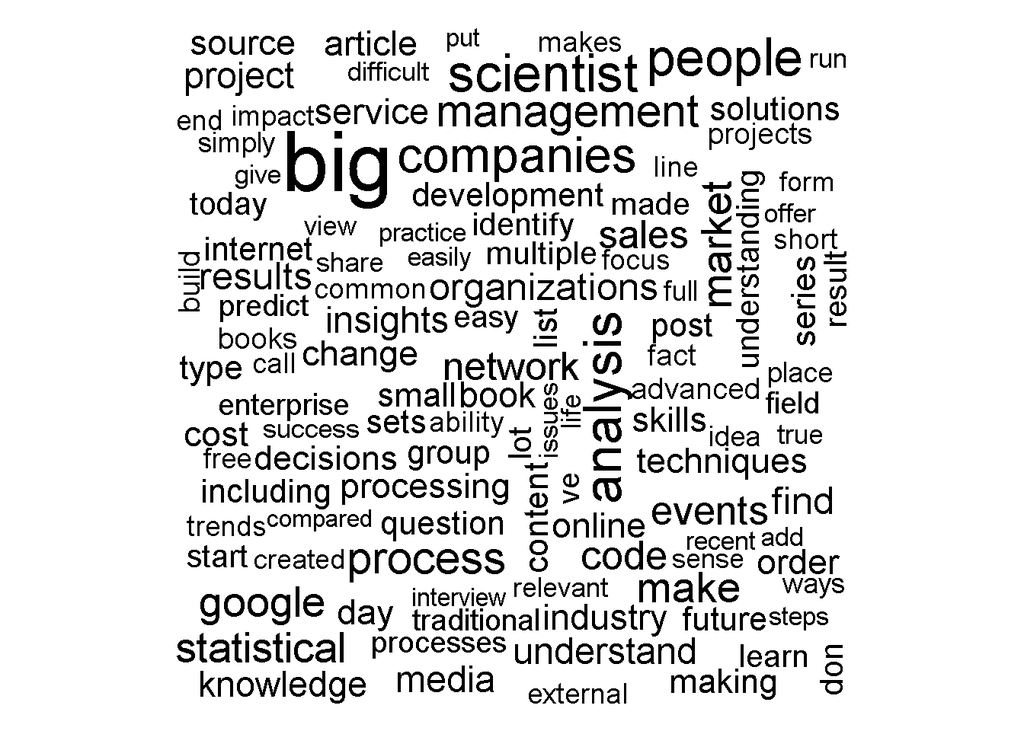

```r
library(wordcloud)
suppressWarnings(wordcloud(names(v),v))
```

Certain words like “analytics”, “hadoop”, “mining” are relevant to data science, and they appear very frequently in the blogs. Yet there’s still a typo “amp”, we do not know what is it exactly, so we just ignore it.

```r
keywords<-removeWords(names(frequentWords),"amp")
keywords<-keywords[keywords!=""]
```

# Find associated words

In order to find the association between words, we use findAssocs tool in tm package. We presume the correlation limites are 0.6 for each word, in order to save time, we just search associated words of the first five words.

```r
associateWords<-findAssocs(tdm,keywords[1:5],0.6)#Find the associated words and return a list
temp<-sapply(associateWords,length)#Show the number of associated words
temp
```

```
##      data analytics   science       big  business
##         4       447         0         6         5
```

Take a look at associated words of “big” and “data”.

```r
associateWords["data"]
```

```
## $data
## statistics     mining   database    machine
##       0.65       0.64       0.63       0.62
```

```r
associateWords["big"]
```

```
## $big
##    statistics        mining      database       machine        hadoop
##          0.79          0.76          0.72          0.72          0.69
## analyticsspss
##          0.62
```

We can see that “data” is associated with “statistics”,“mining”,“database” and “machine”, it is reasonable. If we wanna dig out more relevant words, it will be time-consuming by using findAssocs method. Let’s try some other methods like dendrogram.

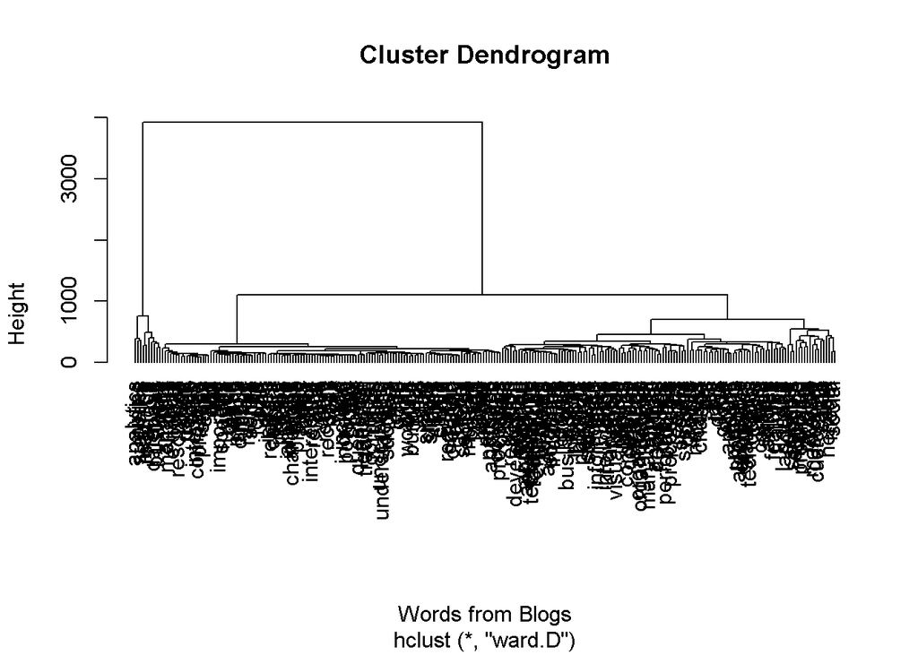

```r
hc<-hclust(dist(removeSparseTerms(tdm,0.9)),method="ward.D")
plot(hc,xlab="Words from Blogs",hang = -1)
```

```r
wordCluster<-cutree(hc,k=8)
wordCluster<-sort(wordCluster)
wordCluster
```

```
##       ability        access           add      analytic       analyze
##             1             1             1             1             1
##        answer      approach          back         based          blog
##             1             1             1             1             1
##          book         books         build      building          call
##             1             1             1             1             1
##        called          case    challenges        common      compared
##             1             1             1             1             1
##       complex        create       created      creating       current
##             1             1             1             1             1
##        detect     difficult           don        easily          easy
##             1             1             1             1             1
##           end      external          fact         field          find
##             1             1             1             1             1
##         focus          form         found          free          full
##             1             1             1             1             1
##        future          give          good         great         helps
##             1             1             1             1             1
##          high        highly          idea      identify        impact
##             1             1             1             1             1
##     important       improve       include      increase   interesting
##             1             1             1             1             1
##     interview        issues         large         learn         level
##             1             1             1             1             1
##          life          line         links          long           lot
##             1             1             1             1             1
##          made         major          make         makes         means
##             1             1             1             1             1
##       members      multiple         offer          part          past
##             1             1             1             1             1
##      patterns         place         point     potential         power
##             1             1             1             1             1
##      practice       predict     processes       provide           put
##             1             1             1             1             1
##      question     questions       quickly          read          real
##             1             1             1             1             1
##        recent      recently       related      relevant      required
##             1             1             1             1             1
##     resources           run         sense         share         short
##             1             1             1             1             1
```

[output cut: 49 more lines]

```
##             2             2             2             2             2
## visualization           web         world          year         years
##             2             2             2             2             2
##           amp      customer     customers      decision        events
##             3             3             3             3             3
##     marketing         model      modeling        models    predictive
##             3             3             3             3             3
##         sales     analytics        mining    statistics           big
##             3             4             4             4             5
##      business          data      database        hadoop      learning
##             5             5             5             5             6
##       machine         media       network        social          text
##             6             7             7             7             7
##       science     scientist    scientists
##             8             8             8
```

```r
index<-wordCluster>1
keywords2<-names(wordCluster[index])
keywords2
```

```
##   [1] "advanced"      "algorithms"    "amount"        "analysis"
##   [5] "analytical"    "application"   "applications"  "article"
##   [9] "articles"      "businesses"    "cases"         "change"
##  [13] "code"          "companies"     "company"       "computer"
##  [17] "content"       "cost"          "day"           "days"
##  [21] "decisions"     "design"        "development"   "enterprise"
##  [25] "experience"    "features"      "financial"     "google"
##  [29] "group"         "growth"        "human"         "including"
##  [33] "industry"      "information"   "insights"      "intelligence"
##  [37] "internet"      "job"           "key"           "knowledge"
##  [41] "language"      "list"          "making"        "management"
##  [45] "market"        "methods"       "metrics"       "news"
##  [49] "number"        "online"        "open"          "order"
##  [53] "organization"  "organizations" "people"        "performance"
##  [57] "platform"      "post"          "problem"       "problems"
```

[output cut: 19 more lines]

We can compare keywords from different methods.

```r
sum(keywords %in% keywords2)
```

```
## [1] 84
```

Almost 90 percent of frequent key words coincidents with those from hierarchy cluster. Therefore, those keywords can represent the topics of blogs.

# Stemming

There are some words appearing with their plus forms in the list, it’s redundance, so we use stem method to get the basic forms.

```r
keywordsStem<-stemDocument(keywords)
keywordsStem<-unique(keywordsStem)
keywordsStem
```

```
##  [1] "data"       "analyt"     "scienc"     "big"        "busi"
##  [6] "learn"      "model"      "inform"     "hadoop"     "analysi"
## [11] "time"       "predict"    "scientist"  "peopl"      "mine"
## [16] "machin"     "statist"    "custom"     "compani"    "social"
## [21] "number"     "process"    "market"     "manag"      "text"
## [26] "softwar"    "databas"    "system"     "decis"      "tool"
## [31] "set"        "research"   "make"       "web"        "googl"
## [36] "job"        "base"       "technolog"  "work"       "problem"
## [41] "event"      "larg"       "product"    "code"       "good"
## [46] "user"       "network"    "organ"      "world"      "top"
## [51] "intellig"   "perform"    "algorithm"  "sale"       "find"
## [56] "real"       "result"     "qualiti"    "project"    "import"
## [61] "servic"     "team"       "year"       "search"     "insight"
## [66] "media"      "understand" "metric"     "articl"     "knowledg"
## [71] "industri"   "experi"     "book"       "thing"      "approach"
## [76] "key"        "case"       "techniqu"   "cost"       "risk"
## [81] "chang"      "applic"     "part"       "onlin"      "creat"
```

We’ll use the result later.

# n-gram Tokenization

Previously, we’ve analyzed the TfIdf weighted single words, in order to extract most frequent long tail terms, we should use 2-grams, 3-grams or 4-grams. Let’s have a look at 2-grams.

```r
library(RWeka)
BigramTokenizer <- function(x) NGramTokenizer(x, Weka_control(min = 2, max = 2))
tdm2<-TermDocumentMatrix(blogs,control=list(tokenize=BigramTokenizer,removePunctuation=T,minDocFreq=5,stopwords=T,weighting = function(x) weightTfIdf(x, normalize = FALSE)))
```

Have a look at those terms.

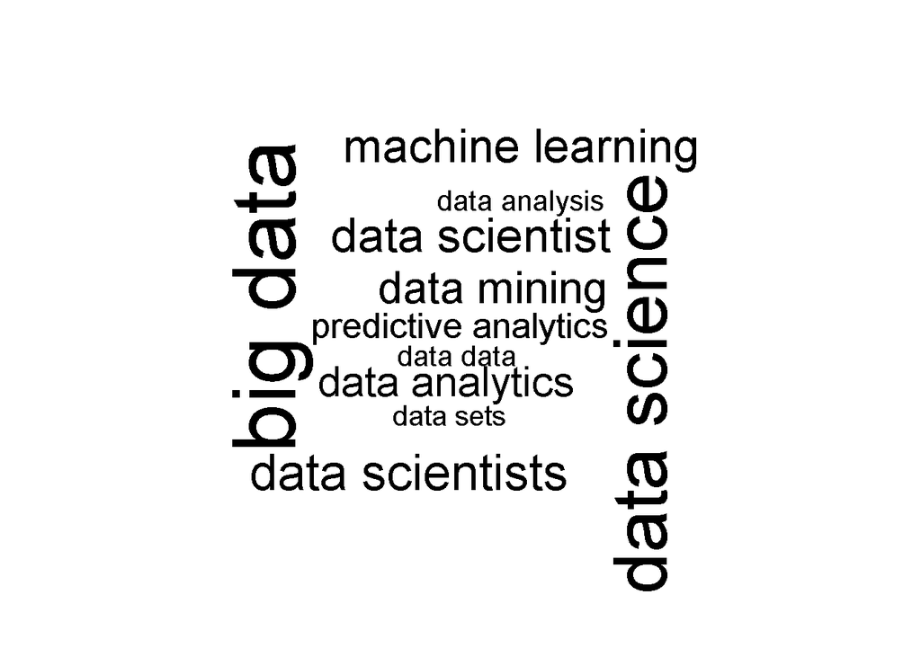

```r
wc2<-as.matrix(removeSparseTerms(tdm2,0.9))
v<-sort(rowSums(wc2),decreasing=T)
suppressWarnings(wordcloud(names(v),v))
```

```r
head(v,20)
```

```
##             big data         data science      data scientists
##             8023.879             6640.474             4073.729
##       data scientist     machine learning          data mining
##             3903.816             3755.656             3507.522
##       data analytics predictive analytics            data data
##             3209.833             2596.483             1894.096
##        data analysis            data sets
##             1829.422             1816.259
```

```r
bigramWords<-names(v)
bigramWords
```

```
##  [1] "big data"             "data science"         "data scientists"
##  [4] "data scientist"       "machine learning"     "data mining"
##  [7] "data analytics"       "predictive analytics" "data data"
## [10] "data analysis"        "data sets"
```

The last term is not quite right in terms of grammar, let’s exlude it and store other terms along with single words obtained above .

```r
bigramWords<-bigramWords[-11]
keyTerms<-c(keywords,usefulTerms)
```

Then look at 3-grams.

```r
TrigramTokenizer <- function(x) NGramTokenizer(x, Weka_control(min = 3, max = 3))
tdm3<-TermDocumentMatrix(blogs,control=list(tokenize=TrigramTokenizer,wordLength=c(2,30),removePunctuation=T,minDocFreq=5,weighting = function(x) weightTfIdf(x, normalize = FALSE)))
wc3<-as.matrix(removeSparseTerms(tdm3,0.95))
v<-sort(rowSums(wc3),decreasing=T)
trigramWords<-names(v)
head(v,20)
```

```
##           big data analytics                big data data
##                    2435.1955                    1155.6408
##            data data science     interview questions data
##                     992.3086                     966.6770
##      job interview questions        types data scientists
##                     960.8047                     896.2190
##          data scientists job         data scientists read
##                     894.7477                     867.1715
##     scientists read practice         short tutorials data
##                     864.7223                     864.7223
##    tutorials data scientists     data sciencedata science
##                     864.7223                     862.2666
##     scientists job interview          practice types data
##                     852.3782                     842.3834
##          read practice types detect spurious correlations
##                     842.3834                     813.1867
##   spurious correlations find            books cheat sheet
##                     813.1867                     806.5344
##   cheat sheet apprenticeship     announcements events rss
##                     806.5344                     803.9205
```

Most of trigrams are relevant to data science, but too specific as general key terms such as “job interview questions”. We select the first one as key term.

```r
trigramWords<-trigramWords[1]
keyTerms<-c(keyTerms,trigramWords[1])
write(keyTerms,"keyTerms.txt")
keyTerms
```

```
##   [1] "data"                 "analytics"            "science"
##   [4] "big"                  "business"             "learning"
##   [7] "model"                "information"          "hadoop"
##  [10] "analysis"             "time"                 "predictive"
##  [13] "scientist"            "people"               "mining"
##  [16] "scientists"           "machine"              "statistics"
##  [19] "customer"             "companies"            "social"
##  [22] "number"               "process"              "company"
##  [25] "marketing"            "management"           "text"
##  [28] "software"             "models"               "database"
##  [31] "system"               "decision"             "customers"
##  [34] "tools"                "set"                  "research"
##  [37] "make"                 "web"                  "statistical"
##  [40] "google"               "job"                  "based"
##  [43] "market"               "technology"           "work"
```

[output cut: 21 more lines]

It’s not likely that relevant terms appearing in 4 or 5 or higher grams, so we do not consider them. And now we have build a keywords list for those blogs.

# Build frequency table

Based on keyword list build above, we are going to explore the contents of blogs in terms of keywords. We have aquired TfIdf weights of words, what we need to do is create data frames, and combine them, then we will get data table which store the weights of keywords in each blog.

```r
unigram_dt<-data.frame(wc)
unigram_dt<-unigram_dt[keywords,]#Build keywords table for unigrams
bigram_dt<-data.frame(wc2)
bigram_dt<-bigram_dt[bigramWords,]#Build bigram table
trigram_dt<-data.frame(wc3)
trigram_dt<-trigram_dt[trigramWords,]#Build trigram table
dt<-rbind(unigram_dt,bigram_dt,trigram_dt)#Combine them
dt<-t(dt)#Transpose it, now each row stands for a blog, and each column stands for a keyword
dt<-data.frame(dt)
```

Now we have created data tables of keywords and blogs. Now we’d better visualize the data in order to get a glimpse of it. But there’re too many columns, therefore, we adopt PCA method to reduce the dimensions.

```r
dt_pca<-prcomp(dt)#Calculate Components
summary(dt_pca)
```

```
## Importance of components:
##                            PC1      PC2    PC3    PC4    PC5     PC6
## Standard deviation     28.3043 10.14708 8.4433 7.7973 6.6602 6.41225
## Proportion of Variance  0.4046  0.05199 0.0360 0.0307 0.0224 0.02076
## Cumulative Proportion   0.4046  0.45655 0.4926 0.5233 0.5457 0.56642
##                            PC7     PC8     PC9    PC10    PC11    PC12
## Standard deviation     5.98969 5.65576 5.53929 5.17867 5.11597 5.00163
## Proportion of Variance 0.01812 0.01615 0.01549 0.01354 0.01322 0.01263
## Cumulative Proportion  0.58454 0.60069 0.61619 0.62973 0.64295 0.65558
##                           PC13    PC14    PC15    PC16    PC17    PC18
## Standard deviation     4.86836 4.79911 4.68586 4.46878 4.40067 4.25479
## Proportion of Variance 0.01197 0.01163 0.01109 0.01008 0.00978 0.00914
## Cumulative Proportion  0.66755 0.67918 0.69027 0.70035 0.71013 0.71927
##                           PC19    PC20    PC21   PC22    PC23    PC24
## Standard deviation     4.12857 4.03366 3.86526 3.7503 3.68829 3.66771
## Proportion of Variance 0.00861 0.00822 0.00754 0.0071 0.00687 0.00679
## Cumulative Proportion  0.72788 0.73610 0.74364 0.7507 0.75761 0.76441
##                           PC25   PC26    PC27    PC28    PC29    PC30
## Standard deviation     3.63486 3.5031 3.46912 3.42812 3.36409 3.35342
## Proportion of Variance 0.00667 0.0062 0.00608 0.00593 0.00571 0.00568
## Cumulative Proportion  0.77108 0.7773 0.78335 0.78929 0.79500 0.80068
##                          PC31    PC32    PC33    PC34    PC35    PC36
## Standard deviation     3.2692 3.25071 3.22100 3.18738 3.15646 3.14120
## Proportion of Variance 0.0054 0.00534 0.00524 0.00513 0.00503 0.00498
## Cumulative Proportion  0.8061 0.81141 0.81665 0.82178 0.82681 0.83180
##                           PC37    PC38    PC39    PC40    PC41    PC42
## Standard deviation     3.10972 3.07280 3.00507 2.94788 2.93442 2.89414
## Proportion of Variance 0.00488 0.00477 0.00456 0.00439 0.00435 0.00423
## Cumulative Proportion  0.83668 0.84145 0.84601 0.85040 0.85475 0.85897
##                           PC43   PC44    PC45   PC46    PC47    PC48
## Standard deviation     2.88877 2.8486 2.81814 2.8134 2.75968 2.72640
## Proportion of Variance 0.00421 0.0041 0.00401 0.0040 0.00385 0.00375
## Cumulative Proportion  0.86319 0.8673 0.87130 0.8753 0.87914 0.88289
##                           PC49    PC50    PC51    PC52    PC53    PC54
## Standard deviation     2.64945 2.63968 2.61967 2.60982 2.55974 2.52231
## Proportion of Variance 0.00354 0.00352 0.00347 0.00344 0.00331 0.00321
## Cumulative Proportion  0.88644 0.88996 0.89342 0.89686 0.90017 0.90338
##                           PC55    PC56    PC57    PC58    PC59    PC60
## Standard deviation     2.49397 2.46748 2.45303 2.42546 2.40705 2.37140
## Proportion of Variance 0.00314 0.00307 0.00304 0.00297 0.00293 0.00284
```

[output cut: 22 more lines]

```
## Standard deviation     1.64465 1.62423 1.6039 1.58854 1.56282 1.53791
## Proportion of Variance 0.00137 0.00133 0.0013 0.00127 0.00123 0.00119
## Cumulative Proportion  0.98414 0.98547 0.9868 0.98805 0.98928 0.99048
##                           PC97    PC98    PC99   PC100   PC101   PC102
## Standard deviation     1.51057 1.47219 1.45363 1.44562 1.38966 1.32574
## Proportion of Variance 0.00115 0.00109 0.00107 0.00106 0.00098 0.00089
## Cumulative Proportion  0.99163 0.99272 0.99379 0.99484 0.99582 0.99671
##                          PC103   PC104   PC105   PC106  PC107   PC108
## Standard deviation     1.23457 1.10041 1.01181 0.93996 0.7737 0.73345
## Proportion of Variance 0.00077 0.00061 0.00052 0.00045 0.0003 0.00027
## Cumulative Proportion  0.99748 0.99809 0.99861 0.99905 0.9993 0.99963
##                          PC109   PC110
## Standard deviation     0.64988 0.56470
## Proportion of Variance 0.00021 0.00016
## Cumulative Proportion  0.99984 1.00000
```

It shows that at least 53 components sum up over 90% of variance. In order to make visualizations, we select the first two components.

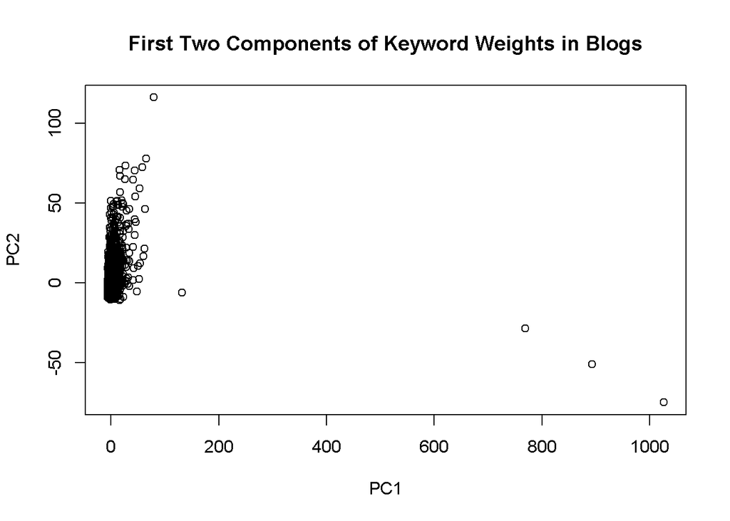

```r
dt_pca2<-dt_pca$x[,1:2]
plot(dt_pca2,main="First Two Components of Keyword Weights in Blogs")
```

There three outliners in the plot, let’s remove them.

```r
index<-dt_pca2[,1]>400
dt_pca2<-dt_pca2[!index,]
dt<-dt[!index,]
```

# Kmeans Clustering

First, we can try k-means clustering first, assume there’re two types.

```r
km<-kmeans(dt,centers=2,iter.max=100)
km$centers
```

```
##       data analytics  science      big business  learning    model
## 1 7.290607  6.773968 8.628147 5.671158 4.437071 5.4319259 3.436752
## 2 1.866853  1.635356 1.252466 1.489451 1.313871 0.7258892 1.096646
##   information    hadoop analysis     time predictive scientist    people
## 1    2.700652 2.5185139 3.367713 3.022087  4.0944058 5.5816362 3.3153869
## 2    1.122951 0.9372399 0.976704 1.029674  0.7783754 0.5699768 0.9533382
##      mining scientists   machine statistics customer companies    social
## 1 2.9044972  4.7633220 3.8942524  3.2131214 2.296987  2.409262 2.6804945
## 2 0.7056509  0.6874713 0.5579123  0.4964719 1.033075  1.006799 0.8400195
##      number   process   company marketing management      text  software
## 1 2.6969429 2.5429452 2.3134948 2.4672835   2.963250 2.9843318 2.0500888
## 2 0.8317219 0.8144094 0.8506591 0.8089696   0.717094 0.6270377 0.8696349
##      models  database    system  decision customers     tools       set
## 1 3.1380657 1.6315061 2.6275981 2.8198637 1.9638626 2.4968927 2.1197973
## 2 0.6777367 0.7379345 0.7592302 0.7197079 0.8580694 0.7660732 0.8289105
##    research      make       web statistical    google       job     based
## 1 2.9262578 2.2301046 2.1827306   2.8470109 2.3142063 2.6189545 2.0781064
## 2 0.6767116 0.7789783 0.7870602   0.6456328 0.7262028 0.6684985 0.7572345
##      market technology      work   problem   systems    events     large
## 1 1.8839166  2.1370735 2.3177815 2.2689099 2.6976168 3.5035394 2.2710272
## 2 0.7850656  0.7201099 0.6869098 0.6894522 0.6120569 0.4684576 0.6659048
##     product     code     good     users   network organization     world
## 1 1.9042975 2.141915 2.157420 1.5838180 2.1730296    2.7657462 1.8949624
## 2 0.7253446 0.683444 0.678646 0.7717447 0.6645915    0.5559499 0.6990742
##         top intelligence performance algorithms     sales     find
## 1 1.7574304    1.9749848   2.3725318  2.6445769 1.7341224 2.046238
## 2 0.7177946    0.6741995   0.5997289  0.5458019 0.7016877 0.631176
##        real  modeling   results   quality organizations   project
## 1 2.1542423 2.4883300 2.0726522 1.6700535     2.2960765 2.1500517
## 2 0.6097597 0.5102342 0.6117284 0.6787418     0.5697105 0.5912642
##        user important  services      team     years    search  insights
## 1 1.5409671 1.9293840 1.8287971 2.1518349 1.9131989 1.7401797 1.8565712
## 2 0.6910093 0.6176954 0.6344341 0.5761483 0.6134111 0.6349983 0.6112845
##    analytic     media understand  metrics articles knowledge  service
## 1 2.1819565 1.6947646   1.948497 2.629558 2.147432 2.1816289 1.619056
## 2 0.5496924 0.6226409   0.573083 0.454285 0.535643 0.5251534 0.616959
##    industry experience      book   things  approach       key      case
## 1 1.2406052  2.0297110 2.0440892 1.747437 1.9368118 1.8293212 1.6308724
## 2 0.6763211  0.5383928 0.5329465 0.582697 0.5497433 0.5632513 0.5966752
##   techniques      cost     risk    change   article applications      year
## 1  2.4953380 1.2803614 1.726749 1.7359722 1.7068977    1.5550062 1.2618965
## 2  0.4451046 0.6538688 0.573213 0.5712468 0.5749385    0.6006796 0.6497385
##        part    online    create big.data data.science data.scientists
## 1 1.7985758 1.3870842 1.7581510 6.182747     7.617198       4.7134057
## 2 0.5580614 0.6261843 0.5616647 1.508102     1.010112       0.6365202
##   data.scientist machine.learning data.mining data.analytics
## 1      5.1214798        3.8035137   2.4116296      2.4898256
## 2      0.5060439        0.4555704   0.5699359      0.5038634
##   predictive.analytics data.data data.analysis big.data.analytics
## 1            2.5800395 1.6114091     1.6014939          1.5985547
## 2            0.4786023 0.3866662     0.3743959          0.3228648
```

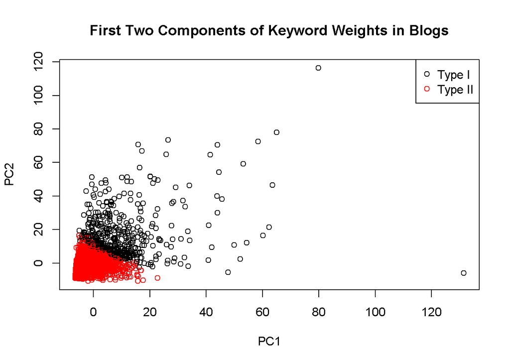

```r
plot(dt_pca2,col=km$cluster,main="First Two Components of Keyword Weights in Blogs")
legend("topright",pch=1,col=c("black","red"),legend = c("Type I", "Type II"))
```

```r
sum(km$cluster==1)#Count of first type
```

```
## [1] 484
```

```r
sum(km$cluster!=1)#count of second type
```

```
## [1] 2816
```

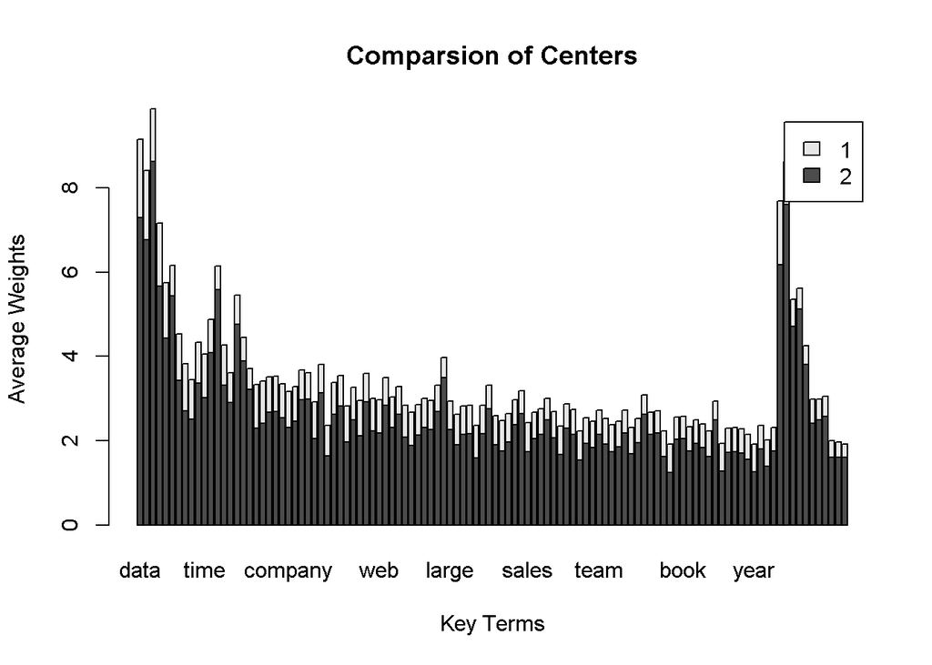

```r
barplot(km$centers,xlab="Key Terms",ylab="Average Weights",main="Comparsion of Centers",legend=unique(km$cluster))
```

And let’s see the variance.

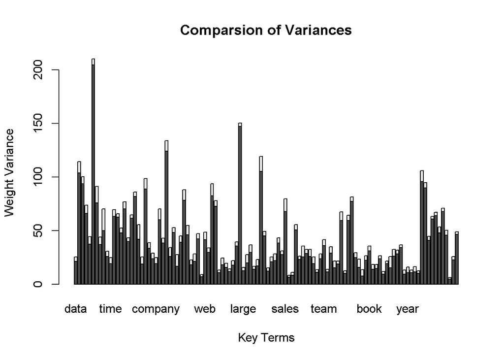

```r
type<-km$cluster
dt1<-dt[type==1,]
dt2<-dt[type!=1,]
var1<-apply(dt1,2,var)
var2<-apply(dt2,2,var)
var_hr<-rbind(var1,var2)
barplot(var_hr,xlab="Key Terms",ylab="Weight Variance",main="Comparsion of Variances")
```

The variances are not quite distinct. We may wonder whether one type of blogs is from specific websites. Let’s extract the names of blog files.

```r
substr<-function(line){sub("^X.","",line)}
files1<-lapply(rownames(dt1),substr)#Remove the first letters of file names
files2<-lapply(rownames(dt2),substr)#Remove the first letters of file names
files1<-removePunctuation(unlist(files1))#Remove the punctuations
files2<-removePunctuation(unlist(files2))
files1_original<-list.files("DSC")#Blogs from DSC
files2_original<-list.files("AnalyticBridge")#Blogs from AB
files1_original<-removePunctuation(files1_original)#Remove the punctuations
files2_original<-removePunctuation(files2_original)
```

Now see the result.

```r
sum(files1 %in% files1_original)/length(files1)
```

```
## [1] 0.7128099
```

```r
sum(files2 %in% files1_original)/length(files2)
```

```
## [1] 0.5110085
```

```r
sum(files1 %in% files2_original)/length(files1)
```

```
## [1] 0.1404959
```

```r
sum(files2 %in% files2_original)/length(files2)
```

```
## [1] 0.3845881
```

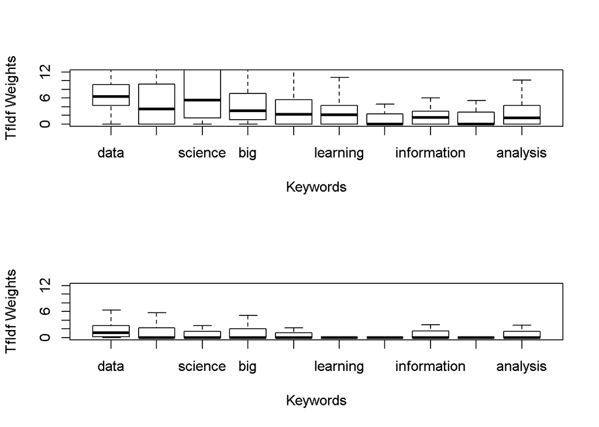

```r
par(mfrow=c(2,1))
boxplot(as.matrix(dt1[,1:10]),outline=F,ylim=c(0,12),xlab="Keywords",ylab="TfIdf Weights")
boxplot(as.matrix(dt2[,1:10]),outline=F,ylim=c(0,12),xlab="Keywords",ylab="TfIdf Weights")
```

# Hierarchy Clustering

Let’s try hierarchy clustering here.

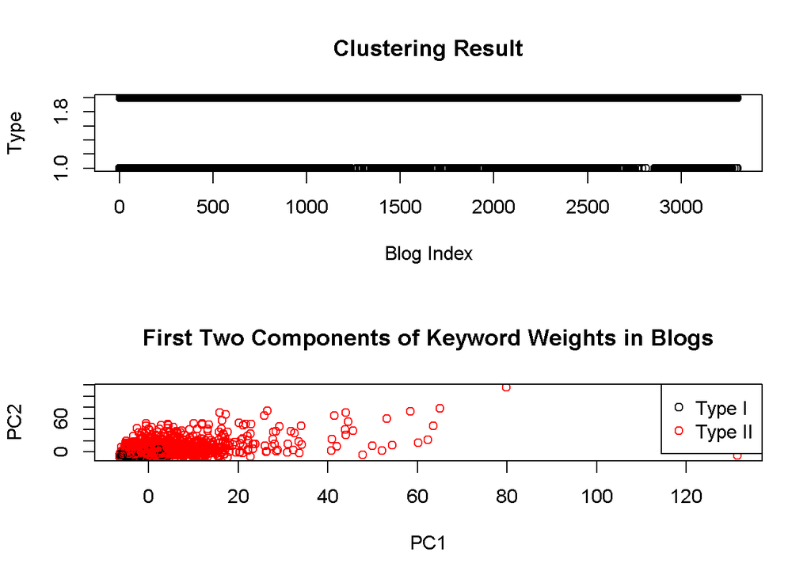

```r
par(mfrow=c(2,1))
hc<-hclust(dist(dt),method="ward.D")
result<-cutree(hc,k=2)
plot(result,xlab="Blog Index",ylab="Type",main="Clustering Result")
plot(dt_pca2,col=result,main="First Two Components of Keyword Weights in Blogs")
legend("topright",pch=1,col=c("black","red"),legend = c("Type I", "Type II"))
```

```r
sum(result==1)
```

```
## [1] 1314
```

```r
sum(result!=1)
```

```
## [1] 1986
```

The result is quite different from that of kmeans. Try to compare the results of two methods by statistical properties.

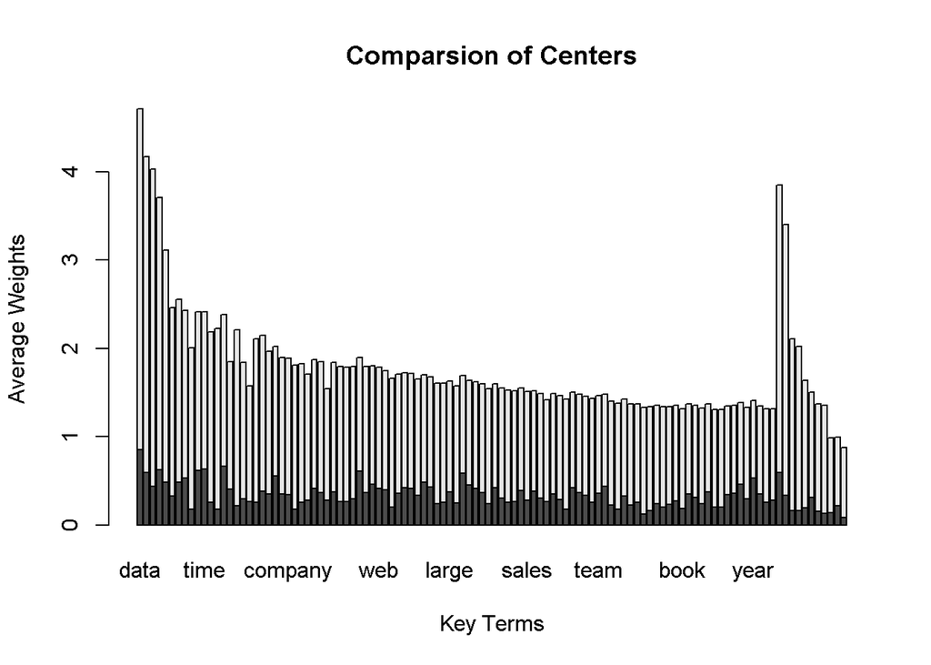

```r
dt3<-dt[result==1,]#The first type
dt4<-dt[result!=1,]#The other type
means3<-apply(dt3,2,mean)
means4<-apply(dt4,2,mean)
centers_hr<-rbind(means3,means4)
barplot(centers_hr,xlab="Key Terms",ylab="Average Weights",main="Comparsion of Centers")
```

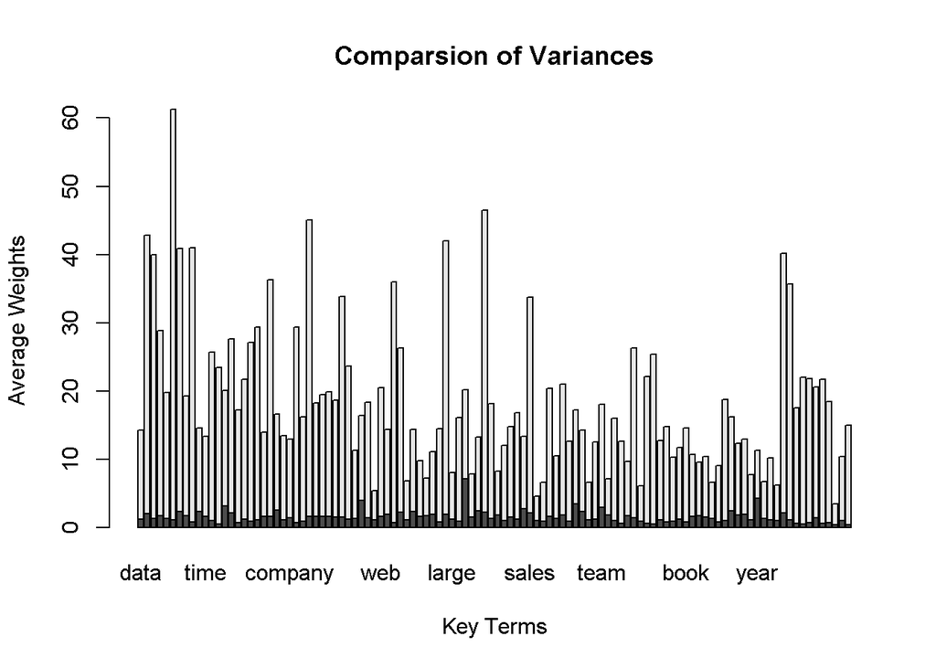

```r
var3<-apply(dt3,2,var)
var4<-apply(dt4,2,var)
var_hr<-rbind(var3,var4)
barplot(var_hr,xlab="Key Terms",ylab="Average Weights",main="Comparsion of Variances")
```

We can see hierarchy clustering perform better than k-means one, the variances are lower and quite distinct.

# Conclusion

TfIdf weights work well in building keywords list from the blogs, and those terms are quite relevant to data science(if stop words removed). We set the weights as blog features, and do unsupervised learning work on the blogs by k-means and hierachy methods. Both methods perform well in clustering, especially hierachy method does better in terms of variances.